# ML

Saturday, November 15, 2014

### Background

Using devices such as Jawbone Up, Nike FuelBand, and Fitbit it is now possible to collect a large amount of data about personal activity relatively inexpensively. These type of devices are part of the quantified self movement – a group of enthusiasts who take measurements about themselves regularly to improve their health, to find patterns in their behavior, or because they are tech geeks. One thing that people regularly do is quantify how much of a particular activity they do, but they rarely quantify how well they do it. In this project, your goal will be to use data from accelerometers on the belt, forearm, arm, and dumbell of 6 participants. They were asked to perform barbell lifts correctly and incorrectly in 5 different ways. More information is available from the website here: http://groupware.les.inf.puc-rio.br/har (see the section on the Weight Lifting Exercise Dataset). This background paragraph was taken from the Practical Machine Learning Course Project page by Jeff Leek, PhD, Roger D. Peng, PhD, Brian Caffo, PhD

```r
#Read files into R
Train <- read.csv("c:/rWork/pml-training.csv", header=T,
                  stringsAsFactors = FALSE)
Test <- read.csv("c:/rWork/pml-testing.csv", header=T,
                 stringsAsFactors = FALSE)
#Set options to no scientific notations and four digits
options(scipen=999, digits=4)
#Activate caret and rpart libraries
library("caret", lib.loc="~/R/win-library/3.1")
library("rpart", lib.loc="~/R/win-library/3.1")
#Separate Training and Test data
inTrain <- createDataPartition(y=Train$classe, p=.8, list=FALSE)
training <- Train[inTrain,]
trainingTest <- Train[-inTrain,]
dim(training); dim(trainingTest)
```

```
## [1] 15699   160
```

```
## [1] 3923  160
```

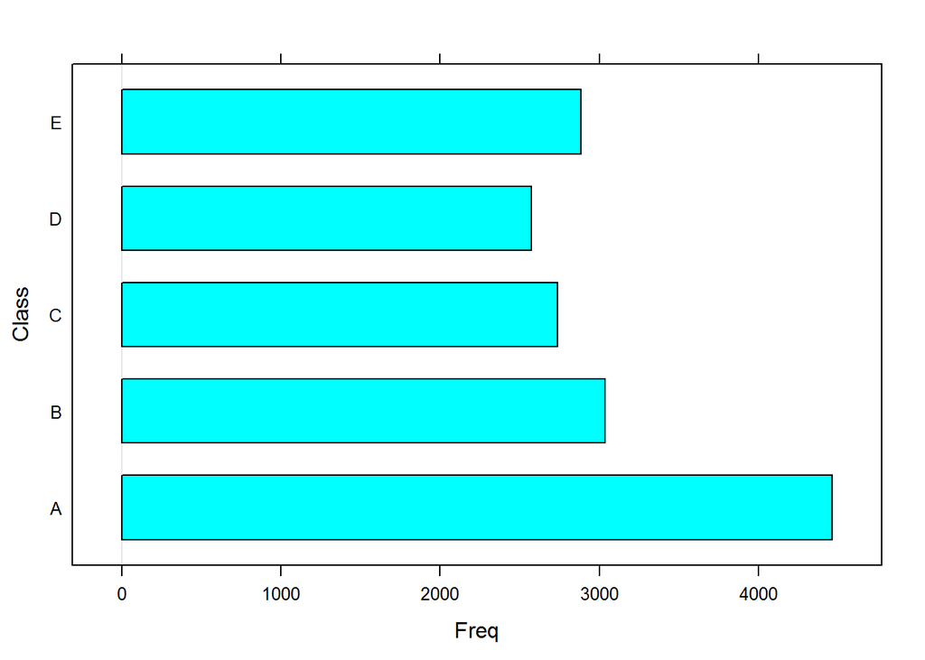

```r
#display the classe variable graphically
barchart(training$classe, horiz=TRUE, ylab="Class")
```

```r
#Fit classe to selected variables
```

### Sample error

```r
modFit <- rpart(classe~X+accel_arm_z+cvtd_timestamp+gyros_dumbbell_y+
                    magnet_belt_y+total_accel_forearm, method="class",
                data=trainingTest)
#Predict the fitted rpart object
pred <- predict(modFit, type = "prob")
# display the results
prcp <- printcp(modFit)
```

```
##
## Classification tree:
## rpart(formula = classe ~ X + accel_arm_z + cvtd_timestamp + gyros_dumbbell_y +
##     magnet_belt_y + total_accel_forearm, data = trainingTest,
##     method = "class")
##
## Variables actually used in tree construction:
## [1] X
##
## Root node error: 2807/3923 = 0.72
##
## n= 3923
##
##     CP nsplit rel error xerror    xstd
## 1 0.27      0      1.00 1.0000 0.01007
## 2 0.26      1      0.73 0.7296 0.01115
## 3 0.24      2      0.47 0.4731 0.01056
## 4 0.23      3      0.23 0.2301 0.00828
## 5 0.01      4      0.00 0.0014 0.00071
```

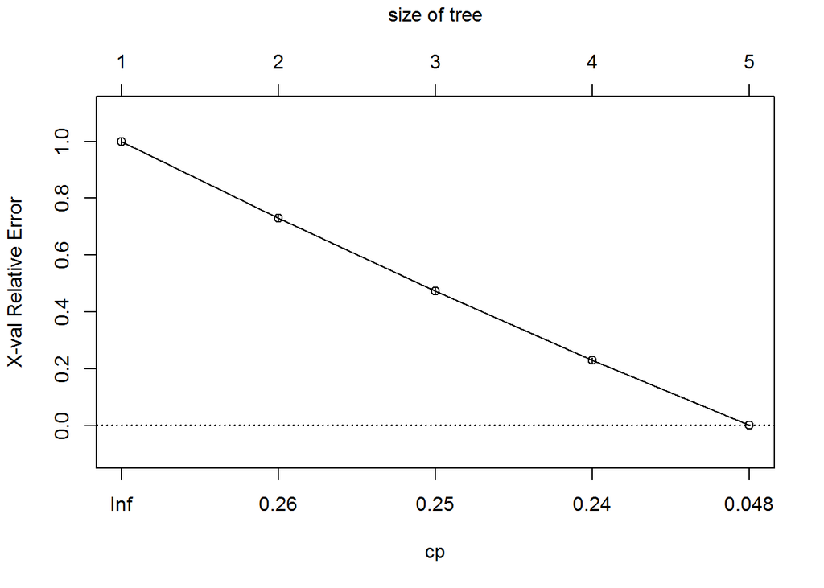

```r
# visualize cross-validation results
plcp <- plotcp(modFit)
```

```r
#detailed summary of splits
summ <- summary(modFit)
```

```
## Call:
## rpart(formula = classe ~ X + accel_arm_z + cvtd_timestamp + gyros_dumbbell_y +
##     magnet_belt_y + total_accel_forearm, data = trainingTest,
##     method = "class")
##   n= 3923
##
##       CP nsplit rel error   xerror      xstd
## 1 0.2704      0    1.0000 1.000000 0.0100670
## 2 0.2569      1    0.7296 0.729605 0.0111459
## 3 0.2437      2    0.4727 0.473103 0.0105588
## 4 0.2291      3    0.2291 0.230139 0.0082757
## 5 0.0100      4    0.0000 0.001425 0.0007121
##
## Variable importance
##                   X      cvtd_timestamp       magnet_belt_y
##                  59                  28                   5
##    gyros_dumbbell_y total_accel_forearm         accel_arm_z
##                   5                   2                   1
##
## Node number 1: 3923 observations,    complexity param=0.2704
##   predicted class=A  expected loss=0.7155  P(node) =1
##     class counts:  1116   759   684   643   721
##    probabilities: 0.284 0.193 0.174 0.164 0.184
##   left son=2 (1116 obs) right son=3 (2807 obs)
##   Primary splits:
##       X                   < 5582   to the left,  improve=998.90, (0 missing)
##       cvtd_timestamp      splits as  LLRRLLRRLLRLLRLRRLLR, improve=598.80, (0 missing)
##       magnet_belt_y       < 557.5  to the right, improve=162.40, (0 missing)
##       gyros_dumbbell_y    < 0.57   to the left,  improve=100.30, (0 missing)
##       total_accel_forearm < 5.5    to the left,  improve= 32.44, (0 missing)
##   Surrogate splits:
##       cvtd_timestamp      splits as  LLRRLLRRLRRLRRLRRLRR, agree=0.880, adj=0.579, (0 split)
##       total_accel_forearm < 5.5    to the left,  agree=0.728, adj=0.045, (0 split)
##
## Node number 2: 1116 observations
##   predicted class=A  expected loss=0  P(node) =0.2845
##     class counts:  1116     0     0     0     0
##    probabilities: 1.000 0.000 0.000 0.000 0.000
##
## Node number 3: 2807 observations,    complexity param=0.2569
```

[output cut: 55 more lines]

```
##
## Node number 15: 721 observations
##   predicted class=E  expected loss=0  P(node) =0.1838
##     class counts:     0     0     0     0   721
##    probabilities: 0.000 0.000 0.000 0.000 1.000
##
## Node number 28: 684 observations
##   predicted class=C  expected loss=0  P(node) =0.1744
##     class counts:     0     0   684     0     0
##    probabilities: 0.000 0.000 1.000 0.000 0.000
##
## Node number 29: 643 observations
##   predicted class=D  expected loss=0  P(node) =0.1639
##     class counts:     0     0     0   643     0
##    probabilities: 0.000 0.000 0.000 1.000 0.000
```